# simplextree: Introduction

## Introduction

Often in the realm of Topological Data Analysis (TDA), the foundational starting point in moving from a “data set” to some type of analysis is the construction of an (abstract) [simplicial complex](https://en.wikipedia.org/wiki/Simplicial_complex). A *simplicial complex* $\mathcal{K}$ defined over a finite vertex set $V$ is a set of non-empty subsets of $V$ satisfying the following two conditions:

1. $$p \in V \implies \{p\} \in \mathcal{K}$$
2. $$\sigma \in \mathcal{K}, \tau \subseteq \sigma \implies \tau \in \mathcal{K}$$

Another way of stating the second condition is that every simplex in the complex is *closed under taking faces*. Each element $\sigma in \mathcal{K}$ is called a simplex or a *face* of $\mathcal{K}$. If $\sigma \in \mathcal{K}$ and $\sigma$ is a $k$-simplex, then $\sigma$ is made up of exactly $k+1$ vertices (or ‘labels’), and the dimension of $\sigma$ is $k$. The dimension of the simplicial complex $\mathcal{K}$ is the largest integer $d$ such that $\mathcal{K}$ contains a $d$-simplex.

There are many ways of constructing of a simplicial complex, each of which offer certain theoretical or computational guarantees. The choice of representation depends on the goal of the analysis. For example, the Čech and Rips constructions are common choices when studying Persistent Homology due to their theoretical guarantees related to homotopy equivalence. Nerve complexes (e.g. the Mapper construction) and Witness complexes[^1] are often used when a more computationally feasible representation is preferred. Delaunay complexes are often used in more geometric settings, such as in mesh-generation, 3D graphics, etc. Each construction admits a certain intrinsic complexity: the Rips complex at parameter $\epsilon$ admits a face for every subset of points which have diameter less than $\epsilon$, the Witness complex scales according to the number of specified landmarks, etc. Whats common among them all these constructions is that their combinatorial aspects can all be represented as abstract simplicial complexes: they all obey the two properties given above. It would be nice to have a simple and elegant data structure capable of representing any simplicial complex, regardless of the chosen construction process.

Enter the *simplex tree*[^2]: a flexible data structure for representing and manipulating general simplicial complexes of any dimension. The best and quickest way to understand the simplex tree structure is with a picture. Here’s one (taken from the paper) depicting a simplicial 3-complex (left) and its corresponding Simplex Tree (right). Each node is in bijection with the faces in the complex: there exactly one node for each face, and each node stores exactly one label.

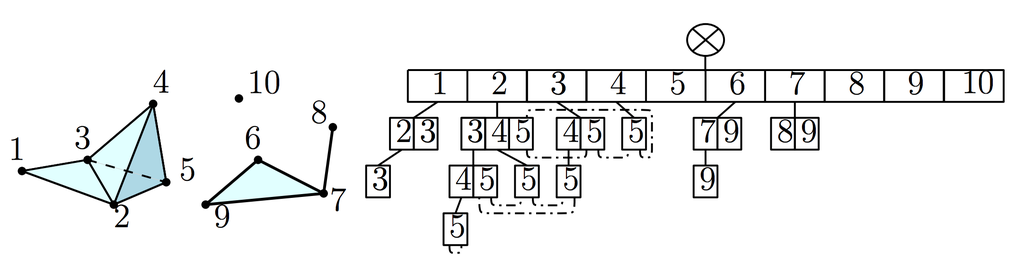

simplex tree figure

The simplex tree can be effectively be thought of as an ordered Trie, a related tree-like data structure that has proven useful in storing and processing words/text corpora. Like a trie, the simplex tree stores just one ‘character’ per node (+ a constant number of extra pointers to maintain the adjacency structure), and each node is associated with with exactly one face in the complex. Unlike a traditional trie, the simplex tree requires a few additional invariants be kept to be called a simplex tree:

1. Each level in the trie is *ordered*
2. Child node labels are strictly greater than their parents
3. Each level beyond dimension $0$ stores additional adjacency relations connecting `cousins’, or nodes with the same label and depth.

An example depicting the 3rd property is illustrated above by the dotted lines connected together the $5$-nodes. These relatively simple modifications give the trie a richer structure, one that is amenable to modification and that scales inline with the intrinsic complexity of corresponding complex.

In what follows, for those interested, I will discuss how some common operations used in tandem with simplicial complexes can be greatly simplified using the simplex tree. I’ll also discuss their associated complexities, and give examples of how to execute such operations using the `simplextree` package.

## Getting started

To get started with the `simplextree` package, one needs a method of constructing a simplicial complex. One option is to start with an empty complex and build it manually.

```r
library(simplextree)
st <- simplex_tree()
print(st)
```

```
< empty simplex tree >
```

On the *R* side, each $k$-simplex is represented as a $(k+1)$-length integer vector containing the labels of the simplex. Inserting simplices into the complex can be done one at a time or specified as a collection via a list, either through the `insert` function or at initialization time via `simplex_tree`. For example, one way to build the triangle $\{1,2,3\}$ is to insert each simplex one-by-one:

```r
st <- simplex_tree()
insert(st, 1)
insert(st, 2)
insert(st, 3)
insert(st, c(1,2))
insert(st, c(1,3))
insert(st, c(2,3))
insert(st, c(1,2,3))
print_simplices(st)
```

```
1, 2, 3, 1 2, 1 3, 2 3, 1 2 3
```

In inserting a simplex $\sigma$, to conform to the properties of being a simplicial complex, all faces of $\sigma$ are also inserted. As a result, its sufficient to specify just the *maximal faces*, i.e. the simplices which are not themselves faces of any other simplex. The same complex above can be constructed more concisely with:

```r
st <- simplex_tree()
insert(st, c(1,2,3))
print_simplices(st)
```

```
1, 2, 3, 1 2, 1 3, 2 3, 1 2 3
```

As another example, consider the complex shown in the figure depicting the data structure. The complex above has ten 0-simplices, twelve 1-simplices, six 2-simplices, and one 3-simplex; these simplices need not be added one by one. All one needs to do is insert the simplices $\{1,2,3\}$, $\{2,3,4,5\}$, $\{6,7,9\}$, $\{7,8\}$, and $\{10\}$.

```r
st <- simplex_tree()
insert(st, list(c(1,2,3), c(2,3,4,5), c(6,7,9), c(7,8), c(10)))
print(st)
```

```
Simplex Tree with (10, 12, 6, 1) (0, 1, 2, 3)-simplices
```

You can also supply the simplices at initialization.

```r
st <- simplex_tree(list(1:3, 2:5, c(6,7,9), 7:8, 10))
print(st)
```

```
Simplex Tree with (10, 12, 6, 1) (0, 1, 2, 3)-simplices
```

The `print_simplices` function gives you multiple ways of printing the simplices in the complex. You can use the *tree* and *cousins* options to see the structure of the underlying simplex tree, the former showing the subtrees rooted at each vertex per line (top-down), and the latter showing how the simplices are stored per level (from the side), for example:

```r
print_simplices(st, "tree")
```

```
1 (h = 2): .( 2 3 )..( 3 )
2 (h = 3): .( 3 4 5 )..( 4 5 5 )...( 5 )
3 (h = 2): .( 4 5 )..( 5 )
4 (h = 1): .( 5 )
5 (h = 0):
6 (h = 2): .( 7 9 )..( 9 )
7 (h = 1): .( 8 9 )
8 (h = 0):
9 (h = 0):
10 (h = 0):
```

To visualize the complex, simply call the `plot` method. The default method uses a force-directed layout algorithm to compute the coordinates in the plot, but you also provide your own:

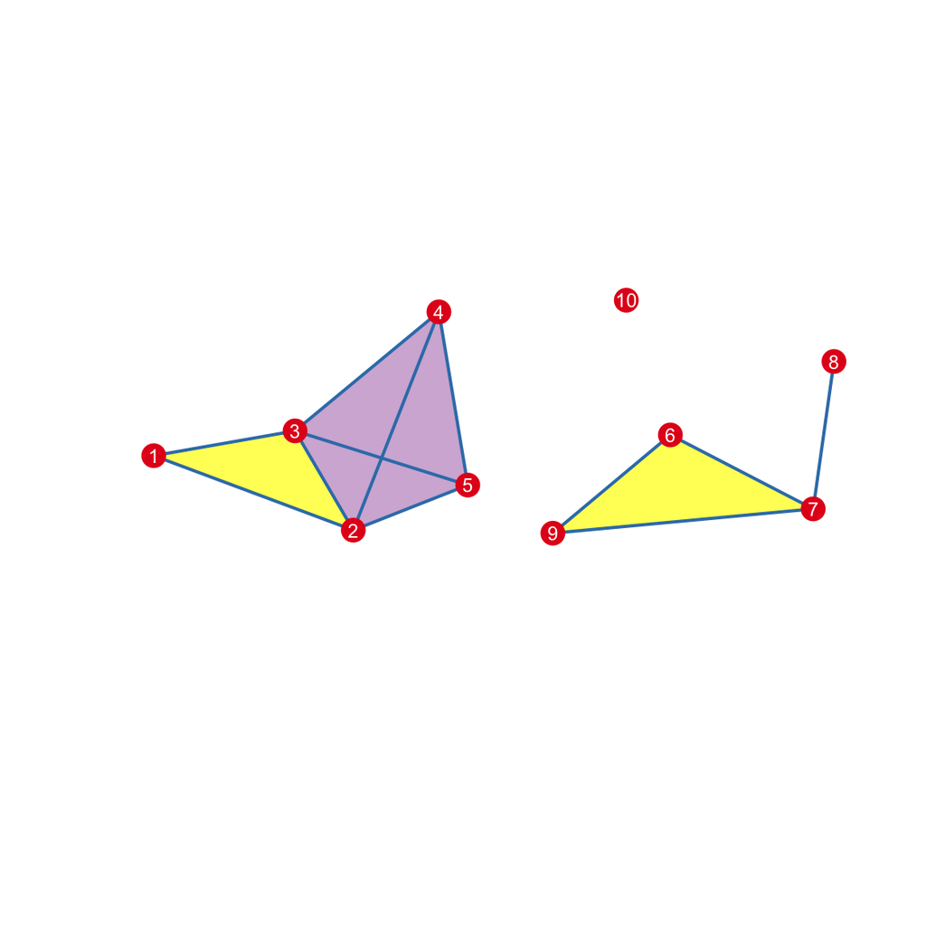

```r
st <- simplex_tree(list(1:3, 2:5, c(6,7,9), 7:8, 10))
coords <- cbind(x=c(57,451,336,620,677,1077,1359,1400,845,990), y=c(305,158,354,589,247,346,200,491,152,612))
plot(st, coords=coords, asp = 1)
```

### Traversals

A *traversal* is an ordered path through a subset of simplices in the simplex tree. If simplices are the atoms from which the simplex tree is created, then traversals are the building blocks from which efficient algorithms can be designed. Traversals form the foundation for many other auxiliary methods—they often provide an elegant starting point when one is tasked with extracting or manipulating parts of the complex, such as faces or cofaces.

As an initial example, consider the classical *preorder* (or “depth-first”) traversal:

```
preorder(node){
  if (node == null)
    return
  visit(node)
  for child_node of node.children
    preorder(child_node)
}
```

Straightforward. On the simplex tree, the simplices along a preorder traversal can be printed concisely with:

```r
## Prints the simplices of each traversal column-wise, i.e. each simplex is a column
print_simplices(preorder(st), format = "column")
```

```
1 1 1 1 2 2 2 2 2 2 2 2 3 3 3 3 4 4 5 6 6 6 6 7 7 7 8 9 10
  2 2 3   3 3 3 3 4 4 5   4 4 5   5     7 7 9   8 9
    3       4 4 5   5       5             9
              5
```

Observe that due to the naturally ordered structure of the simplex tree, the preorder traversal corresponds with a [lexicographical ordering](https://en.wikipedia.org/wiki/Lexicographical_order) of the simplices in the complex. Similarly, the level order traversal (not shown) corresponds with a [shortlex](https://en.wikipedia.org/wiki/Shortlex_order) ordering (i.e. lexicographical per dimension) of the simplices. A related property one can extract from this observation is that every *ancestor* simplex (i.e. a simplex with children) in the trie must be a *face* of any of its descendants. Similarly, every *descendant* simplex must be a *coface* of its ancestors. This naturally constructive property can come in handy in crafting efficient algorithms to manipulate the complex, and to do many basic operations on complex as a whole. Let’s see some examples of this in action.

### Fundamental building blocks

For a moment, forget about the simplex tree, and consider the problem of enumerating all the simplices in an abstract simplicial complex. You can choose how to represent the complex in memory–the time and space complexities of any operation on the complex inherently depend on this choice. The simplest approach might be to represent every simplex explicitly, collecting all simplices as into a list $L = \{ \sigma_1, \sigma_2, \dots, \sigma_m \}$. For example, the full combinatorial description of the 2-simplex $\{1, 2, 3\}$ is represented by the list $L = \{ \{1\}, \{2\}, \{3\}, \{1, 2\}, \{1, 3\}, \{2, 3\}, \{1, 2, 3\} \}$. Since the simplices are already formed, accessing any element of the list is $O(1)$, and thus enumerating the simplices in the complex takes linear time $O(m)$, where $m$ is the number of simplices in the list. However, consider the space tradeoff: although we have constant-time access to any simplex, the simplex labels are increasingly redundant, leading to suboptimal storage complexity. Since each $k$-simplex requires $k+1$ storage, and each simplex has $2^{d+1} - 1$ faces, one can conclude that the storage complexity scales linearly in the number of faces, and exponentially in the dimension of the complex. An easy upper bound for the size of this list is $\approx O(md)$, where $d = \mathrm{dim}(\mathcal{K})$ is the dimension of the largest face in the complex.

At the other extreme, suppose we have happen to have the *maximal* simplices on hand (as shown above), i.e. the largest simplices whose union captures the full complex. For example, going back to the example from the picture, one can store just the maximal faces and then enumerate the lower-order ones with the highly useful `combn` function:

```r
simplices <- list(c(1,2,3), c(2,3,4,5), c(6,7,9), c(7,8), 10)
for (simplex in simplices){
  d <- length(simplex)
  for (k in 1:d){
    combn(d, k, function(i){ print(simplex[i]) })
  }
}
```

```
[1] 1
[1] 2
[1] 3
[1] 1 2
[1] 1 3
[1] 2 3
[1] 1 2 3
[1] 2
[1] 3
[1] 4
[1] 5
[1] 2 3
[1] 2 4
[1] 2 5
[1] 3 4
```

[output cut: 18 more lines]

At first glace, this is a nice and compact solution to representing a complex—but it has some drawbacks. Firstly, it assumes that one already has the maximal simplices on hand. Moreover, non-maximal faces must be generated on the fly (shown above using `simplex[i]`): generating a $k$-face from a higher order face in this way requires at least $O(k + 1)$ operations, as opposed to the $O(1)$ access time with the simple list representation. Since each face requires at most $d = \mathrm{dim}(\mathcal{K})$ operations to access, a worst-case complexity estimate for enumerating all the simplices in the complex is $\approx O(md)$.

The simple list approach uses $O(md)$ storage, but allows $O(1)$ access to a simplex, and thus $O(m)$ complexity to enumerate all simplices. The other approach compresses the complex to use a much smaller amount of storage (roughly $\approx O(kd)$, where $k$ is the number of maximal simplices), but then requires at most $O(d)$ access time for any non-maximal simplex. If the number of vertices $n$ is fixed, then as the dimension of the complex $d$ grows, the number of maximal simplices tends to decrease, until we have a full simplicial $d$-complex. In this case, we have $O(d)$ storage, but now every simplex requires at most $O(d)$ time to access if the approach using `combn` is used above. If there are $m$ simplices, the enumeration problem reduces to $O(md)$ complexity. At first glance, this tradeoff between time and space complexity seems unavoidable.

Instead, consider again the enumeration problem using the simplex tree using, e.g. the *preorder* traversal. As mentioned above, this corresponds to the lexicographical ordering of the faces.

```r
## Prints the simplices of each traversal column-wise, i.e. each simplex is a column
st <- simplex_tree(list(1:3, 2:5, c(6,7,9), 7:8, 10))
print_simplices(preorder(st), format = "column")
```

```
1 1 1 1 2 2 2 2 2 2 2 2 3 3 3 3 4 4 5 6 6 6 6 7 7 7 8 9 10
  2 2 3   3 3 3 3 4 4 5   4 4 5   5     7 7 9   8 9
    3       4 4 5   5       5             9
              5
```

Observe that in the sequence of simplices printed above, at most one label and at most one dimension changes per visited node. Imagine that during the traversal, one keeps a single vector of length at most $d$ around in memory, whose last entry is to be iteratively modified with the label of the current node in the traversal. In going from a $k$-simplex to a $(k+1)$-simplex, the vector has a new label appended and increases in size by 1—all other labels are unaffected (and are correct). Similarly, in traversing upwards in the trie (descending in dimension) from $(k+1)$-simplex to a $k$-simplex, the vector shrinks in size by 1 and again has its last label modified. Regardless, the time it takes to form the labels corresponding to any individual simplex is *constant*: one size change, and one label change. The complexity of enumerating the simplices is the sum of the complexities of accessing each simplex: thus, enumerating the simplices with a preorder traversal takes *linear time*, $\approx O(m)$, in the size of complex. And, since each node stores only one label, we achieve an $\approx O(m)$ size as well[^3].

In summary, ordered *traversals* on the simplex tree may confer certain computational advantages that simplify common operations on a simplicial complex. The example above is perhaps the simplest such operation: enumerating all simplices in the complex. In the next couple sections, I’ll demonstrate how other types of traversals provide computationally attractive “building blocks” for performing other types of common operations on the complex.

[output not shown]

### Building from the blocks

Each *traversals* in the `simplextree` package is specified independently at the package-level. The first argument to every traversal is the complex to traverse through; other arguments, where applicable, parameterize certain aspects of the traversal. Given a parameterized traversal, one can use the `traverse` function to apply a function on each simplex. The general pattern is

```
st <- simplex_tree(...)
traverse(traversal_type(st, ...), function(simplex){ ... })
```

As a quick example, consider being tasked with a slightly modified version of the enumeration problem above: create a function to collect the set of simplices of dimension $\leq k$ (i.e. the $k$-skeleton of $\mathcal{K}$) into a list. How would you do it?

Easy way out: just enumerate all the simplices, keeping only those with dimension $\leq k$.

```r
k <- 2
skeleton <- list()
traverse(preorder(st), function(simplex){
  if (length(simplex) <= (k+1)){
    skeleton <<- append(skeleton, list(simplex))
  }
})
print_simplices(skeleton, format = "column")
```

```
1 1 1 1 2 2 2 2 2 2 2 3 3 3 3 4 4 5 6 6 6 6 7 7 7 8 9 10
  2 2 3   3 3 3 4 4 5   4 4 5   5     7 7 9   8 9
    3       4 5   5       5             9
```

The problem: what if $\mathrm{dim}(\mathcal{K}) >> k$? Since the majority of the simplices will have lengths $> k$, the majority of the time will be spent enumerating subtrees corresponding to simplices that will never be needed. This may seem like a trivial concern from a user-perspective, but simplicial complexes are frequently built from representations that are inherently combinatorial. One of the unfortunate consequences of this is that they often scale exponentially in the size of input, and as a result what appears to be a trivial concern may turn out to be a very nontrivial computational problem.

Consider the popular [Rips complex](https://en.wikipedia.org/wiki/Vietoris%E2%80%93Rips_complex), which is a geometric [flag complex](https://en.wikipedia.org/wiki/Clique_complex), i.e. a simplicial complex whose higher order simplices are determined by the $1$-skeleton entirely. An easy way of getting a random Rips complex is to first form a graph by e.g. sampling $n$ points from the unit square, connecting points pairwise with an edge if they are within distance $2 \epsilon$ of each other. The Rips complex up to dimension $k$ can be recovered by inserting higher order cliques via e.g. an *expansion* algorithm. A natural question to ask is how quickly does the complex grow based on the parameter $\epsilon$?

```r
set.seed(1234)
for (eps in seq(0.10, 0.50, by=0.10)){
  G <- igraph::sample_grg(nodes = 35, radius = eps)
  st <- simplex_tree(as.list(seq(igraph::vcount(G)))) %>% insert(t(igraph::as_edgelist(G)))
  st %>% expand(k=max(st$degree(st$vertices)))
  cat(sprintf("Parameter=%g, n_simplices=%d:\n", eps, sum(st$n_simplices)))
  print(structure(st$n_simplices, names=seq(0, st$dimension)))
  cat("\n")
}
```

[output not shown]

If one just wants the enumerate the $k$-skeleton of the complex, filtering out higher-order simplices isn’t enough: the traversal should not recurse beyond dimension $k$. The fix is easy enough:

```
preorder(node, k){
  if (node == null)
    return
  visit(node)
  if (node.dimension < k){
    for child_node of node.children
      preorder(child_node, f)
  }
}
```

You can enumerate the $k$-skeleton of a complex like so with the `simplextree` package.

```r
st <- simplex_tree(list(1:3, 2:5, c(6,7,9), 7:8, 10))
print_simplices(st %>% k_skeleton(k = 2L), format = "column")
```

[output not shown]

Enumerating the $k$-simplices follows a similar pattern: we skip nodes with dimension $< k$, and don’t recurse beyond dimension $k$. The only changes to pseudocode above would be something like `if (node.dimension == k){ visit(node) }`. Of course, these traversal extensions are available in `simplextree`.

```r
st <- simplex_tree(list(1:3, 2:5, c(6,7,9), 7:8, 10))
print_simplices(st %>% k_simplices(k = 2L), format = "column")
```

[output not shown]

Concluding this warmup, we’ve seen that in starting with some very standard algorithms (i.e. a preorder/“depth-first” tree traversal) on the simplex tree data structure, it is straightforward derive efficient algorithms to perform common operations sought after in interacting with a simplicial complex.

### Enumerating cofaces

Recall the any abstract simplicial complex $\mathcal{K}$ is closed under taking faces: for every $\sigma \in \mathcal{K}$, if $\tau \subseteq \sigma$, then $\tau$ must also be in $mathcal{K}$. If $\tau \subseteq \sigma$, $\tau$ is said to be a *face* of $\sigma$. This definitions has a dual as well: if $\tau \subseteq \sigma$, then $\sigma$ is said to be a *coface* of $\tau$. That is, the set faces/cofaces of $\sigma$ are the simplices $\tau$ satisfying, respectively:
$$\text{faces}(\sigma) = \{\tau \in \mathcal{K}, \tau \subseteq \sigma \}$$
$$\text{cofaces}(\sigma) = \{ \, \tau \in \mathcal{K}, \, \sigma \subseteq \tau \, \}$$
In both definitions, $\sigma$ is itself both face and coface of itself. As shown above, enumerating the faces of a simplex is easy enough: given a $(d+1)$-simplex, one can enumerate all $k$-length combinations where $k \leq d + 1$ with `combn`:

```r
sigma <- c(1,2,3,4)
d <- length(sigma)
faces <- lapply(1:d, function(k){
  combn(d, k, FUN = function(i){ sigma[i] }, simplify = FALSE)
})
faces <- unlist(faces, recursive = FALSE) ## flatten one layer deep
print_simplices(faces, format = "column")
```

This doesn’t even require a simplex tree structure (after all, given $\sigma$, its faces *must* be in the trie, by the definition of a simplicial complex). But now consider the problem of computing cofaces. How would you go about doing it naively, i.e. with just a list of simplices?

One way, of course, is to just enumerate all the simplices in the complex, and just record which ones contain $\sigma$ as a subset. But this takes $\approx O(2md)$ comparisons, where $m = \lVert \mathcal{K} \rVert$, and $d = \mathrm{dim}(\mathcal{K})$. There is a more efficient way.

If one wants to find the cofaces of $\sigma = \{v_1 v_2 \dots v_k\}$, then any simplex $\tau \in \mathcal{K}$ with labels of the form $\{\ast v_0 \ast v_1 \ast \dots \ast v_k \ast \}$ counts as a coface, where $\ast$ is any vertex label (or empty) in $\mathcal{K}$. To decompose the problem into simpler steps, first consider finding simplices with labels $\{\ast v_0 \ast v_1 \ast \dots \ast v_k \}$. Since we are looking for cofaces, we only need consider simplices whose dimensions are greater than $\sigma$, and since these particular simplices end in $v_k$, they must be encoded in the adjacency relations linking ‘cousins’ at the same depth (in the picture shown above, the ‘cousins’ nodes recording the $5$ label are linked).

We now exploit the face/coface property, as before. Since every coface $\tau$ of a given simplex $\sigma$ must include $\sigma$ itself, we explicitly look at dimensions higher than $\mathrm{dim}(\sigma)$. Similarly, since every ancestor is face of its descendants, all of the descendants of $\sigma$ are cofaces of $\sigma$. Thus, only the nodes representing the roots of these subtrees are needed to fully describe the cofaces.

```r
st$print_cousins()
```

```r
print_simplices(coface_roots(st, 3))
```

[output not shown]

```r
print_preorder <- function(simplex){ print_simplices(simplex %>% preorder(st, .)) }
st %>%
  coface_roots(3) %>%
  traverse(print_preorder)
```

To expand the lower-order faces automatically, use the `cofaces` traversal directly:

```r
print_simplices(cofaces(st, 3))
```

[output not shown]

## Example 2: maximal faces

Now consider the problem of enumerating the *maximal faces* of a complex. A *maximal face* $\sigma \in \mathcal{K}$ is a simplex that not a face of any other simplex in $\mathcal{K}$. Such simplices correspond with the ‘largest’ simplices previously mentioned; they are also the simplices used in the `simplextree` constructor below.

```r
st <- simplex_tree(list(1:3, 2:5, c(6,7,9), 7:8, 10))
coords <- cbind(x=c(57,451,336,620,677,1077,1359,1400,845,990), y=c(305,158,354,589,247,346,200,491,152,612))
plot(st, coords=coords, asp = 1)
```

[output not shown]

In order of dimension, they are $\{10\}$, $\{7,8\}$, $\{6,7,9\}$, $\{1,2,3\}$, and $\{2,3,4,5\}$. How might go about finding them?

By the definition of a simplicial complex, if a simplex $\sigma \in mathcal{K}$ is not a face of any other simplex in $\mathcal{K}$, then *it has no cofaces*, aside from itself. Thus, we should be able to just enumerate all the simplices in the complex—for each simplex $\sigma$, we check to see how many cofaces it has. If it has only one (itself), it must be maximal. We have a way of traversing the complex efficiently (preorder), and we have an efficient means of enumerating the cofaces for any given simplex.

```r
maximal_faces <- list()
traverse(preorder(st), function(sigma){
  sigma_cofaces <- as.list(cofaces(st, sigma))
  if (length(sigma_cofaces) == 1){
    maximal_faces <<- append(maximal_faces, list(sigma))
  }
})
print_simplices(maximal_faces)
```

[output not shown]

Sure enough, this works, but it can be made even more efficient: for each $\sigma \in \mathcal{K}$, rather than enumerating all the cofaces, it is enough to just check whether $\sigma$ has *any* cofaces aside from itself. To do that, note that if $\sigma$ has any children, it is not maximal, and otherwise the only thing left to do is check if $\sigma$’s label exists anywhere in the tree at a depth greater than $\mathrm{depth}(\sigma)$. Checking the existence of a given label at any depth can be done by looking at the cousins: at depth $k$, if there are $m$ simplices, then this should take at most $O((d-k) \log (m-k))$ time. To see this, consider the worst case scenario where one has a fully connected $4$-complex:

```r
st <- simplex_tree(1:5)
st$print_cousins()
```

[output not shown]

```r
st <- simplex_tree(list(1:3, 2:5, c(6,7,9), 7:8, 10))
print_simplices(st %>% maximal())
```

[output not shown]

## From maximal faces to cliques

A *k-clique* is a complete subgraph that has $k$ vertices, i.e. a subgraph if called a *k-clique* there exists an edge between every combination of $k$ vertices. A *maximal* clique is a clique that cannot be extended by adding another vertex–intuitively, they can be thought of as the ‘largest’ complete subgraphs which, when unioned together, yield the graph one started with. A simplicial complex may or may not have a $k+1$-simplex for every maximal cliques; for example the open triangle $\mathcal{K} = \{1, 2, 3, \{1,2\}, \{1,3\}, \{2,3\}\}$ has as its maximal simplices $\{\{1,2\}, \{1,3\}, \{2,3\}\}$, while it’s maximal clique is the simplex $\{1,2,3\}$.

```r
st <- simplex_tree(combn(3,2))
print_simplices(st)
print_simplices(maximal(st))
```

[output not shown]

Let’s see ways of approaching this problem that uses the simplex tree structure. Instead of the maximal-clique problem, I’ll consider the smaller problem of enumerating all maximal cliques *up to dimension k*. That is, we consider a clique to be maximal only if it involves $k$-vertices or less. First, recall the example complex used above:

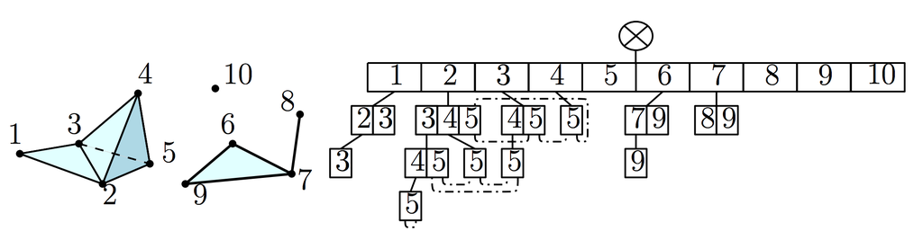

simplex tree figure

In this case, the maximal cliques actually do correspond with the maximal faces of the complex, so instead suppose we only have the graph of this complex:

```r
coords <- cbind(x=c(57,451,336,620,677,1077,1359,1400,845,990), y=c(305,158,354,589,247,346,200,491,152,612))
edge_pairs <- function(simplex){ combn(length(simplex), 2, function(i){ simplex[i] }) }
edges <- do.call(cbind, list(edge_pairs(1:3), edge_pairs(2:5), edge_pairs(c(6,7,9))))
st <- simplex_tree(edges) %>% insert(list(7:8, 10))
plot(st, coords=coords, asp = 1)
```

[output not shown]

The $k$-cliques correspond set of $k$ vertices which are all pairwise connected. In the above example, the $k=3$ cliques correspond to the complete subgraphs formed from the vertices $\{1,2,3\}$, $\{2,3,4\}$, $\{2,4,5\}$, $\{3,4,5\}$, $\{2,3,5\}$, and $\{6,7,9\}$. How can we detect these cliques? It is not at all clear how to do so efficiently.

Let’s look more at the trie structure of the simplex tree.

```r
print_simplices(st, "tree")
```

[output not shown]

One can deduce a recursive procedure for proceeding with the rest of the complex. For every detected $k$-clique, we may choose to insert a $(k-1)$-simplex back into complex, thus ‘expanding’ the complex. Doing this for all simplices in the complex is what’s called *expansion of order k*, or *k-expansion* for short.

We can see which simplices were inserted via asymmetric difference

```r
s1 <- as.list(st %>% level_order())
s2 <- as.list(st %>% expand(k = 2) %>% level_order())
print_simplices(setdiff(s2,s1))
```

[output not shown]

```r
st %>%
  expand(k = 2) %>%
  plot(coords=coords, asp = 1)
```

## TDA application example 2. Computing the Rips complex

```r
library(simplextree)



simplices <- list(list(1,2), list(3,4,1:2,2:3), list(3:4,c(1,4)), list(c(1,3)), list(1:3), list(c(1,3,4)))
layout(matrix(1:6, nrow=2, byrow=TRUE))
st <- simplex_tree()
for (sigma in simplices){
  st %>%
    insert(sigma) %>%
    plot(text_opt=list(labels=letters[st$vertices]))
}

st %>% insert(as.list(1:5)) %>% plot()
st %>% insert(combn(1:5, 2, simplify = FALSE)) %>%  plot()
st %>% insert(1:3) %>% plot()
```

## Example 3. Computing the Euler characteristic curve on a sliding window

```r
sapply(maximal(st), function(sigma){
  combn(sigma, length(sigma), FUN = function(cc){ })
})
```

```r
st <- pbgrad::r_geometric_complex(15, 0.20, dim = 2, coords = TRUE)
xy <- attr(st, "coords")


## Use mod 2 + existing fields to calculate characteristic
euler_characteristic <- function(st){
  sum(st$n_simplices*((-1)^(0:st$dimension %% 2)))
}
print(euler_characteristic(st))
```

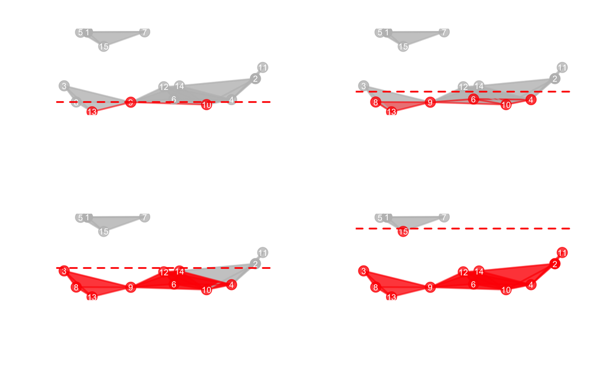

```r
## Helper function to calculate lower-star function values
vertex_heights <- structure(xy[,2], names = st$vertices)

## Create the lower-star structure weights, in shortlex order
fy <- straverse(level_order(st), function(simplex){
  max(vertex_heights[as.character(simplex)])
})

## Plot the lower-stars w/ function values less than the median
thresholds <- quantile(xy[,2], probs = c(0.20, 0.40, 0.60, 0.80))
layout(matrix(1:4, ncol = 2, byrow = TRUE))
for (h in thresholds){
  plot(st, coords = attr(st, "coords"), color_pal = ifelse(fy <= h, "red", "gray"))
  abline(h =  h, col = "red", lty = 2, lwd = 2)
}
```

```r
## Helper functions to calculate lower-star function values
vertex_height <- structure(xy[,2], names = st$vertices)
lower_star <- function(simplex){ max(vertex_height[as.character(simplex)]) }
simplex2str <- function(simplex){ paste0(as.character(simplex), collapse = ",") }

## Create the lower-star structure weights, in shortlex order
shortlex <- level_order(st)
fy <- structure(
  .Data = straverse(shortlex, lower_star),
  names = straverse(shortlex, simplex2str)
)

## Plot the lower-stars w/ function values less than the median
thresholds <- quantile(xy[,2], probs = c(0.20, 0.40, 0.60, 0.80))
layout(matrix(1:4, ncol = 2, byrow = TRUE))
for (h in thresholds){
  plot(st, coords = attr(st, "coords"), color_pal = ifelse(fy <= h, "red", "gray"))
  abline(h =  h, col = "red", lty = 2, lwd = 2)
}
```

```r
fy_max <- fy
rev_shortlex <- rev(as.list(shortlex))
for (simplex in rev_shortlex){
  k <- length(simplex)
  if (k > 1){
    proper_faces <- combn(simplex, k-1, simplex2str)
    fy_max[proper_faces] <- fy_max[simplex2str(simplex)]
  }
}

thresholds <- quantile(xy[,2], probs = c(0.20, 0.40, 0.60, 0.80))
layout(matrix(1:4, ncol = 2, byrow = TRUE))
for (h in thresholds){
  plot(st, coords = attr(st, "coords"), color_pal = ifelse(fy_max <= h, "red", "gray"))
  abline(h =  h, col = "red", lty = 2, lwd = 2)
}
```

Suppose we want to compute the Euler characteristic on a sliding window

```r
str2simplex <- function(simplex){ paste0(as.character(simplex), collapse = ",") }

simplices <- lapply(names(fy[fy <= 0.40]), function(s){ as.integer(unlist(strsplit(s, ","))) })
```

```r
## Choose a set of thresholds
thresholds <- quantile(fy, probs = seq(0, 1, length.out = 20))

## Get the simplex function values and dimension, ordered by weight
fy_ordered <- fy[order(fy)]
fd_ordered <- rep.int(seq(st$dimension+1), times = st$n_simplices)[order(fy)]

## Bin simplices into buckets by dimension, then cumulatively count the size of the buckets
counts_per_dimension <- sapply(seq(st$dimension+1), function(d){
  cumsum(tabulate(findInterval(fy_ordered[fd_ordered == d], thresholds)))
})

## Euler Characteristic Curve
modulus <- ((-1)^(0:st$dimension %% 2))
ecc <- colSums(t(counts_per_dimension)*modulus)

plot(ecc, type = "l", main = "")
```

```r
# simplex_to_string <- function(simplex){ paste0(as.character(simplex), collapse = ",") }
# keys <-
#
# fx <- structure(rep(0, length(keys)), names = keys)
#
# fx[as.character(st$vertices)] <- xy[,2]

# euler characteristic on a sliding window
```

```r
remove.packages("simplextree")


G <- igraph::sample_grg(20, 0.20, coords = TRUE)

st <- simplex_tree(as.list(1:igraph::vcount(G)))
insert(st, igraph::as_edgelist(G))
st$expand(2)
xy <- with(igraph::vertex.attributes(G), {
  cbind(x,y)
})


jsonlite::toJSON(list(nodes=1:igraph::vcount(G), edges=st$edges, polygons=list(st$triangles)))
simplices <- list(coords = xy, nodes=letters[1L:(igraph::vcount(G)-1L)], edges=st$edges-1L, polygons=list(st$triangles-1L, st$quads-1L))
wut <- jsonlite::toJSON(simplices, pretty = TRUE, auto_unbox = FALSE)

microbenchmark::microbenchmark({
  st$expand(2)
}, setup = {
  st <- simplex_tree(as.list(1:igraph::vcount(G)))
  insert(st, igraph::as_edgelist(G))
})

# Unit: milliseconds
#                  expr      min       lq     mean   median       uq      max neval
#  {     st$expand(2) } 3.494911 3.747423 4.521941 3.956999 4.147819 11.60263   100


microbenchmark::microbenchmark({
  st$expand(2)
}, setup = {
  st <- simplex_tree()
  st$insert(as.list(1:igraph::vcount(G)))
  E <- igraph::as_edgelist(G)
  edges <- lapply(1:nrow(E), function(i){ E[i,] })
  st$insert(edges)
})
# Unit: milliseconds
#                  expr      min       lq    mean   median       uq      max neval
#  {     st$expand(2) } 63.03884 64.60097 65.9168 65.68367 66.79374 76.15908   100
```

## Conclusion

In summary, the simplex tree provides an efficient data structure for manipulating simplicial complexes that balances scalability and generality. While other structures may more be better suited to specific families of constructions, the skeleton-blockers or tidy set data structures for encoding flag complexes, the delaunay complex for surface mesh generation, etc., the simplex tree lies at an abstraction scale between the specialized constructions and the “simple” solution using just a list. As shown above, the structure in many ways is a natural structure for representing general simplicial complexes.

## References

### Detour: Side-effects

Note that `insert` inserts the given simplex(es), and then returns the complex invisibly. That is, `insert`, `remove`, `collapse`, and many other functions enact *side-effects*, wherein the underlying object (the simplicial complex) is changed. No copies are made. This can be surprising to some `R` users, who are used to each and every line effectively being independent from the last, or who are used to being able to isolate changes with the assignment operator. For example, consider:

```r
st <- simplex_tree()
st2 <- st
insert(st, 1)
print(st)
```

```
Simplex Tree with (1) (0)-simplices
```

```r
print(st2)
```

```
Simplex Tree with (1) (0)-simplices
```

Notice that modifying `st` after also affects `st2` (and vice versa!). This happens because `<-` does not create a copy in this case; `st` and `st2` are references to the same underlying object. You can create a new copy with e.g. `st2 <- clone(st)`. Note this only copies the simplices themselves; nothing else.

Methods which modify the underlying `simplextree` object follow the same pattern: the first argument is always the complex, and the function always returns the modified object [invisibly][https://www.rdocumentation.org/packages/base/versions/3.6.2/topics/invisible]. This allows many operations which modify the complex to be chained, e.g. yet another way of achieving the insertions above would be to do something like `st %>% insert(c(1,2,3)) %>% insert(c(2,3,4,5)) %>% ...`, etc. This pattern is known as [method chaining](https://adv-r.hadley.nz/r6.html#method-chaining), and has grown commonplace in the [tidyverse](https://www.tidyverse.org/) collection of packages.

[^1]: De Silva, Vin, and Gunnar E. Carlsson. “Topological estimation using witness complexes.” SPBG 4 (2004): 157-166.
[^2]: Boissonnat, Jean-Daniel, and Clément Maria. “The simplex tree: An efficient data structure for general simplicial complexes.” Algorithmica 70.3 (2014): 406-427.
[^3]: This is admittedly a bit of an oversimplification. It is true that the storage complexity of the simplex tree is linear in the size of the complex: if there are $m$ simplices in the complex, then there are $m$ nodes in the simplex tree. However, here I’m using the word RAM interpretation in reporting the complexities; a more accurate description is that the simplex tree requires $\Theta(m \log n)$ space/bits, since each label requires $\Theta(\log n)$ bits to be represented.